# **Project: Twitter US Airline Sentiment**

### **Background and Context:**

Twitter possesses 330 million monthly active users, which allows businesses to reach a broad population and connect with customers without intermediaries. On the other hand, there’s so much information that it’s difficult for brands to quickly detect negative social mentions that could harm their business.

That's why sentiment analysis/classification, which involves monitoring emotions in conversations on social media platforms, has become a key strategy in social media marketing.

Listening to how customers feel about the product/service on Twitter allows companies to understand their audience, keep on top of what’s being said about their brand and their competitors, and discover new trends in the industry.

### **Data Description:**

A sentiment analysis job about the problems of each major U.S. airline. Twitter data was scraped from February of 2015 and contributors were asked to first classify positive, negative, and neutral tweets, followed by categorizing negative reasons (such as "late flight" or "rude service").

### **Dataset:**

The dataset has the following columns:

- tweet_id
- airline_sentiment
- airline_sentiment_confidence
- negativereason
- negativereason_confidence
- airline
- airline_sentiment_gold
- name
- negativereason_gold
- retweet_count
- text
- tweet_coord
- tweet_created
- tweet_location
- user_timezone

### **Download and Load the Libraries**

```python
# The contractions library is not available by default in Google Colab. Need to install it once.
!pip install contractions    # Comment out after the first run, so that this doesn't run multiple times.
```

```python
# First the basic set of libraries needed to number and dataframe processing
import numpy as np
import pandas as pd
import seaborn as sns

import re, string, unicodedata                          # Import Regex, string and unicodedata.
import contractions                                     # Import contractions library.
from bs4 import BeautifulSoup                           # Import BeautifulSoup.

import nltk                                             # Import Natural Language Tool-Kit.

nltk.download('stopwords')                              # Download Stopwords.
nltk.download('punkt')
nltk.download('wordnet')

from nltk.corpus import stopwords                       # Import stopwords.
from nltk.tokenize import word_tokenize, sent_tokenize  # Import Tokenizer.
from nltk.stem.wordnet import WordNetLemmatizer         # Import Lemmatizer.
import matplotlib.pyplot as plt
from sklearn import metrics
from sklearn.metrics import confusion_matrix
```

```python
# Now import the libraries I will need to do the machine learning algorithms
from sklearn.feature_extraction.text import CountVectorizer
from sklearn.feature_extraction.text import TfidfVectorizer

from sklearn.model_selection import train_test_split

from sklearn.ensemble import RandomForestClassifier
from sklearn.model_selection import cross_val_score
```

## **Load The Data and Inspect it**

```python
from google.colab import drive
drive.mount('/content/drive')
```

```python
tweets = pd.read_csv("/content/drive/MyDrive/Colab Notebooks/Tweets.csv")
```

```python
tweets.shape
```

```
(14640, 15)
```

```python
# Take a look at the first few records.
tweets.head(5)
```

|  | tweet_id | airline_sentiment | airline_sentiment_confidence | negativereason | negativereason_confidence | airline | airline_sentiment_gold | name | negativereason_gold | retweet_count | text | tweet_coord | tweet_created | tweet_location | user_timezone |
| --- | --- | --- | --- | --- | --- | --- | --- | --- | --- | --- | --- | --- | --- | --- | --- |
| 0 | 570306133677760513 | neutral | 1.0000 | NaN | NaN | Virgin America | NaN | cairdin | NaN | 0 | @VirginAmerica What @dhepburn said. | NaN | 2015-02-24 11:35:52 -0800 | NaN | Eastern Time (US & Canada) |
| 1 | 570301130888122368 | positive | 0.3486 | NaN | 0.0000 | Virgin America | NaN | jnardino | NaN | 0 | @VirginAmerica plus you've added commercials to the experience... tacky. | NaN | 2015-02-24 11:15:59 -0800 | NaN | Pacific Time (US & Canada) |
| 2 | 570301083672813571 | neutral | 0.6837 | NaN | NaN | Virgin America | NaN | yvonnalynn | NaN | 0 | @VirginAmerica I didn't today... Must mean I need to take another trip! | NaN | 2015-02-24 11:15:48 -0800 | Lets Play | Central Time (US & Canada) |
| 3 | 570301031407624196 | negative | 1.0000 | Bad Flight | 0.7033 | Virgin America | NaN | jnardino | NaN | 0 | @VirginAmerica it's really aggressive to blast obnoxious "entertainment" in your guests' faces &amp; they have little recourse | NaN | 2015-02-24 11:15:36 -0800 | NaN | Pacific Time (US & Canada) |
| 4 | 570300817074462722 | negative | 1.0000 | Can't Tell | 1.0000 | Virgin America | NaN | jnardino | NaN | 0 | @VirginAmerica and it's a really big bad thing about it | NaN | 2015-02-24 11:14:45 -0800 | NaN | Pacific Time (US & Canada) |

## **Exploratory Data Analysis**

```python
# Let's look at the list of columns in the data
tweets.info()
```

```
<class 'pandas.core.frame.DataFrame'>
RangeIndex: 14640 entries, 0 to 14639
Data columns (total 15 columns):
 #   Column                        Non-Null Count  Dtype
---  ------                        --------------  -----
 0   tweet_id                      14640 non-null  int64
 1   airline_sentiment             14640 non-null  object
 2   airline_sentiment_confidence  14640 non-null  float64
 3   negativereason                9178 non-null   object
 4   negativereason_confidence     10522 non-null  float64
 5   airline                       14640 non-null  object
 6   airline_sentiment_gold        40 non-null     object
 7   name                          14640 non-null  object
 8   negativereason_gold           32 non-null     object
 9   retweet_count                 14640 non-null  int64
 10  text                          14640 non-null  object
 11  tweet_coord                   1019 non-null   object
 12  tweet_created                 14640 non-null  object
 13  tweet_location                9907 non-null   object
 14  user_timezone                 9820 non-null   object
dtypes: float64(2), int64(2), object(11)
memory usage: 1.7+ MB
```

The following columns appear to have a lot of data missing and may not be useful for sentiment analysis. I will plan to drop these columns later on.

- negativereason
- negativereason_confidence
- airline_sentiment_gold
- negativereason_gold
- tweet_coord
- tweet_location
- user_timezone

Apart from this, the tweet_id is not a very useful information for sentiment analysis as it is just a unique identifier for each of the tweets. I will drop that column as well.

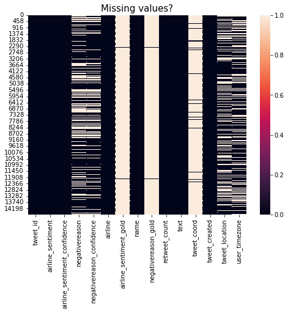

```python
# I want to visualize the amount of missing data in the tweets metadata by plotting the information.
# This technique is taken the MLS session where we did a similar plot.
plt.figure(figsize=(8,6))
sns.heatmap(tweets.isnull())                                  #Visualization of missing value using heatmap
plt.title("Missing values?", fontsize = 15)
plt.show()
```

```python
# Instead of creating my own utility functions, I am reusing some functions
# that were used in various MLS sessions.

# I have enhanced the function that was used in class to be able to display a
# single feature or two features.
# In the case of two features, the second feature is rendered through the hue.
# I have also enhanced the function to sort the results by the height of the
# column instead of by the name of the column.

# function to create labeled barplots

def labeled_barplot(data, feature, feature2=None, perc=False, n=None):
    """
    Barplot with percentage at the top

    data: dataframe
    feature: dataframe column that primarily drives x axis
    feature2: dataframe column that drives the hue of the related items of the major x-axis feature
    perc: whether to display percentages instead of count (default is False)
    n: displays the top n category levels (default is None, i.e., display all levels)
    """

    total = len(data[feature])  # length of the column
    count = data[feature].nunique()

    count2 = 1;
    if ( feature2 is not None ):
      count2 = data[feature2].nunique()

    if n is None:
        n = count
        plt.figure(figsize=(count2*(count + 1), 10))
    else:
        plt.figure(figsize=(count2*(n + 1), 10))

    plt.xticks(rotation=90, fontsize=15)
    if ( feature2 is None ):
      # Plot the single feature, sorting the columns based on the height
      # of the main feature (value_count())
      ax = sns.countplot(
          data=data,
          x=feature,
          order=data[feature].value_counts().index[:n],
      )
    else:
      # Plot with the second feature as a hue, sorting the columns based
      # on the height of the main feature (value_count())
      ax = sns.countplot(
          data=data,
          x=feature,
          hue=feature2,
          order=data[feature].value_counts().index[:n],
      )

    for p in ax.patches:
        if perc == True:
            label = "{:.1f}%".format(
                100 * p.get_height() / total
            )  # percentage of each class of the category
        else:
            label = p.get_height()  # count of each level of the category

        x = p.get_x() + p.get_width() / 2  # width of the plot
        y = p.get_height()  # height of the plot

        ax.annotate(
            label,
            (x, y),
            ha="center",
            va="center",
            size=12,
            xytext=(0, 5),
            textcoords="offset points",
        )  # annotate the percentage

    plt.show()  # show the plot
```

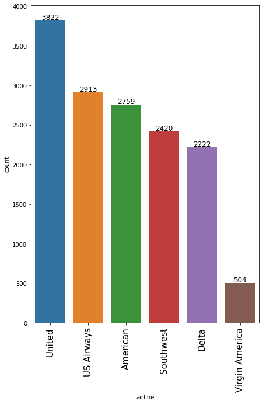

```python
# Let's see the distribution of tweets by airlines to get an idea about who got how much tweets. This is prior to
# getting a sense of the sentiments expressed in each tweet.
labeled_barplot(tweets, "airline")
```

**Observation:** Most comments received by United (26%). The middle of the pack is made up of US Airways, American, Southwest, and Delta. Virgin America gets very few tweets compared to the rest of the airlines (only 3.4%).

Here I have only looked at the volume of tweets by airlines without digging deeper into the sentiments expressed in those tweets.

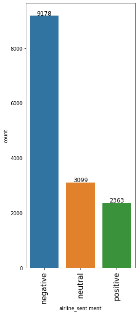

```python
# Plot the distribution of sentiments across all tweets, regardless of the airlines
labeled_barplot(tweets, 'airline_sentiment')
```

**Observation:** Overwhelmingly negative sentiments with 9178 of 14640 tweets being negative (63%). So people are mostly not happy with the airlines and their performance, or else people who are mostly dissatisfied are the ones who tweet about their experience with an airlines.

Positive sentiments make up only 16% of the tweets.

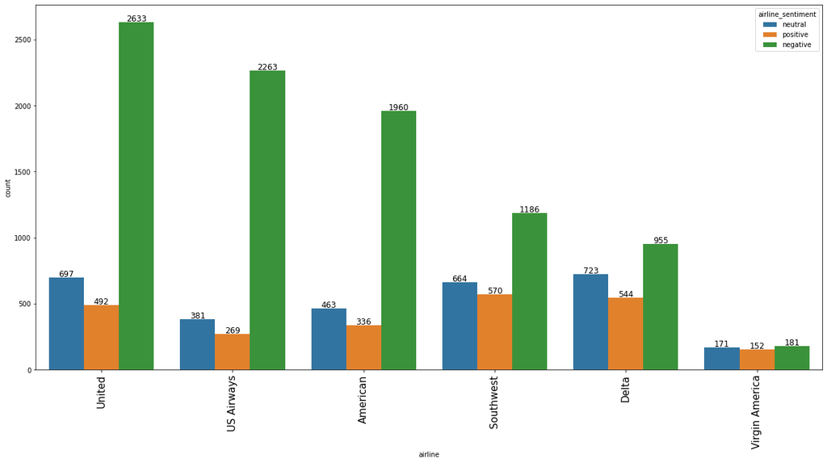

```python
# Look at the sentiment of the tweets by specific airlines.
labeled_barplot(tweets, "airline", "airline_sentiment")
```

**Observation:** The data shows that some airlines have received a lot more negative tweets than others. Let me frame these numbers as a percentage of the total tweets that a specific airline gets. This will give me an idea of how each airline is faring in terms of customer sentiments.

- **United** --> Negative = 69%; Positive = 13%
- **US Airways** --> Negative = 78%; Positive = 9%
- **American** --> Negative = 71%; Positive = 12%
- **Southwest** --> Negative = 49%; Positive = 24%
- **Delta** --> Negative = 43%; Positive = 24%
- **Virgin America** --> Negative = 36%; Positive = 30%

Given this distribution, it appears that although tweets related to **Virgin America** are the fewest, it gets the largest percentage of positive tweets of all the airlines.

**US Airways** gets the smallest percentage of positive tweets, at 9%, while 78% of the tweets about US Airways is negative. This airline is really doing poorly in customer sentiment.

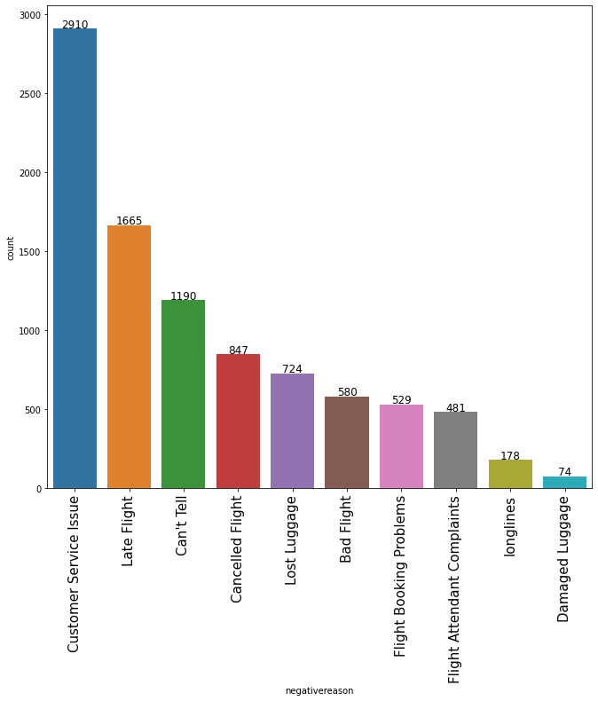

```python
# We see a lot of negative sentiments for all airlines. Let's look at the type of negative sentiments received.
labeled_barplot(tweets, 'negativereason')
```

Although there are only 9178 records with data for reasons for negative sentiments, we get a good picture of the nature of the negative sentiments.

- People are complaining the most about customer service (32%).
- This is closely followed by flights that are late (18%), and flights that are cancelled (9.2%).
- There are 724 instances of lost luggage (8%).
- These should show up in the negative sentiments word cloud when I get to plotting that.

## **Data Pre-processing**

This is where I will be removing unwanted columns, tokenizing the text, and generally preparing the tweets data for sentiment analysis.

Since word-cloud cannot be done unless the data cleaned up and tokenzied, the work-count plotting is also going to be done in this section rather than in the EDA section.

```python
# Let's get rid of all columns that are not going to be useful for sentiment analysis
cols_to_retain = ['airline_sentiment', 'airline', 'text']
tweets = tweets.loc[:, cols_to_retain]
```

```python
# Verify that we only have a subset of columns
tweets.shape
```

```
(14640, 3)
```

```python
# Inspect the data once again, but before doing that, let's expand the amount of text
# that can be displayed, else we are not able to see much of the text data.

# Set option to display the entire text without any truncation.
pd.set_option('display.max_colwidth', None)

# I am going to display 15 records, else I am not able to see the cleanup
tweets.head(15)
```

|  | airline_sentiment | airline | text |
| --- | --- | --- | --- |
| 0 | neutral | Virgin America | @VirginAmerica What @dhepburn said. |
| 1 | positive | Virgin America | @VirginAmerica plus you've added commercials to the experience... tacky. |
| 2 | neutral | Virgin America | @VirginAmerica I didn't today... Must mean I need to take another trip! |
| 3 | negative | Virgin America | @VirginAmerica it's really aggressive to blast obnoxious "entertainment" in your guests' faces &amp; they have little recourse |
| 4 | negative | Virgin America | @VirginAmerica and it's a really big bad thing about it |
| 5 | negative | Virgin America | @VirginAmerica seriously would pay $30 a flight for seats that didn't have this playing.\nit's really the only bad thing about flying VA |
| 6 | positive | Virgin America | @VirginAmerica yes, nearly every time I fly VX this “ear worm” won’t go away :) |
| 7 | neutral | Virgin America | @VirginAmerica Really missed a prime opportunity for Men Without Hats parody, there. https://t.co/mWpG7grEZP |
| 8 | positive | Virgin America | @virginamerica Well, I didn't…but NOW I DO! :-D |
| 9 | positive | Virgin America | @VirginAmerica it was amazing, and arrived an hour early. You're too good to me. |
| 10 | neutral | Virgin America | @VirginAmerica did you know that suicide is the second leading cause of death among teens 10-24 |
| 11 | positive | Virgin America | @VirginAmerica I &lt;3 pretty graphics. so much better than minimal iconography. :D |
| 12 | positive | Virgin America | @VirginAmerica This is such a great deal! Already thinking about my 2nd trip to @Australia &amp; I haven't even gone on my 1st trip yet! ;p |
| 13 | positive | Virgin America | @VirginAmerica @virginmedia I'm flying your #fabulous #Seductive skies again! U take all the #stress away from travel http://t.co/ahlXHhKiyn |
| 14 | positive | Virgin America | @VirginAmerica Thanks! |

At this point, the free-form tweet text needs to be cleaned up. Steps include

1. Remove HTML tags
2. Remove special characters and punctuation
3. Remove all the numbers from the text
4. Tokenize the words
5. Remove stopwords
6. Convert to lowercase

```python
# Use BeautifulSoup to remove the HTML tags from the text.
tweets['text'] = tweets['text'].apply(lambda x: BeautifulSoup(x, "html.parser").get_text())

# Inspect to make sure that HTML tags have been cleaned up. Display 15 records, not 5.
tweets.head(15)
```

|  | airline_sentiment | airline | text |
| --- | --- | --- | --- |
| 0 | neutral | Virgin America | @VirginAmerica What @dhepburn said. |
| 1 | positive | Virgin America | @VirginAmerica plus you've added commercials to the experience... tacky. |
| 2 | neutral | Virgin America | @VirginAmerica I didn't today... Must mean I need to take another trip! |
| 3 | negative | Virgin America | @VirginAmerica it's really aggressive to blast obnoxious "entertainment" in your guests' faces & they have little recourse |
| 4 | negative | Virgin America | @VirginAmerica and it's a really big bad thing about it |
| 5 | negative | Virgin America | @VirginAmerica seriously would pay $30 a flight for seats that didn't have this playing.\nit's really the only bad thing about flying VA |
| 6 | positive | Virgin America | @VirginAmerica yes, nearly every time I fly VX this “ear worm” won’t go away :) |
| 7 | neutral | Virgin America | @VirginAmerica Really missed a prime opportunity for Men Without Hats parody, there. https://t.co/mWpG7grEZP |
| 8 | positive | Virgin America | @virginamerica Well, I didn't…but NOW I DO! :-D |
| 9 | positive | Virgin America | @VirginAmerica it was amazing, and arrived an hour early. You're too good to me. |
| 10 | neutral | Virgin America | @VirginAmerica did you know that suicide is the second leading cause of death among teens 10-24 |
| 11 | positive | Virgin America | @VirginAmerica I <3 pretty graphics. so much better than minimal iconography. :D |
| 12 | positive | Virgin America | @VirginAmerica This is such a great deal! Already thinking about my 2nd trip to @Australia & I haven't even gone on my 1st trip yet! ;p |
| 13 | positive | Virgin America | @VirginAmerica @virginmedia I'm flying your #fabulous #Seductive skies again! U take all the #stress away from travel http://t.co/ahlXHhKiyn |
| 14 | positive | Virgin America | @VirginAmerica Thanks! |

**Observation:** There were not HTML tags in the firt 5 rows, so the cleanup is not obvious. But the existing data has not been mangled.

```python
# Now remove contractions from the text.
tweets['text'] = tweets['text'].apply(lambda x: contractions.fix(x))

# Inspect to make sure that contractions have been removed. Display 15 records, not 5.
tweets.head(15)
```

|  | airline_sentiment | airline | text |
| --- | --- | --- | --- |
| 0 | neutral | Virgin America | @VirginAmerica What @dhepburn said. |
| 1 | positive | Virgin America | @VirginAmerica plus you have added commercials to the experience... tacky. |
| 2 | neutral | Virgin America | @VirginAmerica I did not today... Must mean I need to take another trip! |
| 3 | negative | Virgin America | @VirginAmerica it is really aggressive to blast obnoxious "entertainment" in your guests' faces & they have little recourse |
| 4 | negative | Virgin America | @VirginAmerica and it is a really big bad thing about it |
| 5 | negative | Virgin America | @VirginAmerica seriously would pay $30 a flight for seats that did not have this playing.\nit is really the only bad thing about flying VA |
| 6 | positive | Virgin America | @VirginAmerica yes, nearly every time I fly VX this “ear worm” will not go away :) |
| 7 | neutral | Virgin America | @VirginAmerica Really missed a prime opportunity for Men Without Hats parody, there. https://t.co/mWpG7grEZP |
| 8 | positive | Virgin America | @virginamerica Well, I did not…but NOW I DO! :-D |
| 9 | positive | Virgin America | @VirginAmerica it was amazing, and arrived an hour early. you are too good to me. |
| 10 | neutral | Virgin America | @VirginAmerica did you know that suicide is the second leading because of death among teens 10-24 |
| 11 | positive | Virgin America | @VirginAmerica I <3 pretty graphics. so much better than minimal iconography. :D |
| 12 | positive | Virgin America | @VirginAmerica This is such a great deal! Already thinking about my 2nd trip to @Australia & I have not even gone on my 1st trip yet! ;p |
| 13 | positive | Virgin America | @VirginAmerica @virginmedia I am flying your #fabulous #Seductive skies again! you take all the #stress away from travel http://t.co/ahlXHhKiyn |
| 14 | positive | Virgin America | @VirginAmerica Thanks! |

**Observation:** We see that **you've** has been replaced with **you have**; **didn't** has been replaced with **did not**; **it's** has been replaced with **it is**.

```python
# Now remove all numbers from the text.
tweets['text'] = tweets['text'].apply(lambda x: re.sub(r'\d+', '', x))

# Inspect to make sure that all numbers have been removed. Display 15 records, not 5.
tweets.head(15)
```

|  | airline_sentiment | airline | text |
| --- | --- | --- | --- |
| 0 | neutral | Virgin America | @VirginAmerica What @dhepburn said. |
| 1 | positive | Virgin America | @VirginAmerica plus you have added commercials to the experience... tacky. |
| 2 | neutral | Virgin America | @VirginAmerica I did not today... Must mean I need to take another trip! |
| 3 | negative | Virgin America | @VirginAmerica it is really aggressive to blast obnoxious "entertainment" in your guests' faces & they have little recourse |
| 4 | negative | Virgin America | @VirginAmerica and it is a really big bad thing about it |
| 5 | negative | Virgin America | @VirginAmerica seriously would pay $ a flight for seats that did not have this playing.\nit is really the only bad thing about flying VA |
| 6 | positive | Virgin America | @VirginAmerica yes, nearly every time I fly VX this “ear worm” will not go away :) |
| 7 | neutral | Virgin America | @VirginAmerica Really missed a prime opportunity for Men Without Hats parody, there. https://t.co/mWpGgrEZP |
| 8 | positive | Virgin America | @virginamerica Well, I did not…but NOW I DO! :-D |
| 9 | positive | Virgin America | @VirginAmerica it was amazing, and arrived an hour early. you are too good to me. |
| 10 | neutral | Virgin America | @VirginAmerica did you know that suicide is the second leading because of death among teens - |
| 11 | positive | Virgin America | @VirginAmerica I < pretty graphics. so much better than minimal iconography. :D |
| 12 | positive | Virgin America | @VirginAmerica This is such a great deal! Already thinking about my nd trip to @Australia & I have not even gone on my st trip yet! ;p |
| 13 | positive | Virgin America | @VirginAmerica @virginmedia I am flying your #fabulous #Seductive skies again! you take all the #stress away from travel http://t.co/ahlXHhKiyn |
| 14 | positive | Virgin America | @VirginAmerica Thanks! |

```python
# Now that some of the initialization has been done, we have to tokenize the text into words in order
# to do the rmeaining cleanup based on stemming or lemmatization
tweets['text'] = tweets.apply(lambda row: nltk.word_tokenize(row['text']), axis=1)

# Inspect to make sure that the text has all been tokenized. Display 15 records, not 5.
tweets.head(15)
```

|  | airline_sentiment | airline | text |
| --- | --- | --- | --- |
| 0 | neutral | Virgin America | [@, VirginAmerica, What, @, dhepburn, said, .] |
| 1 | positive | Virgin America | [@, VirginAmerica, plus, you, have, added, commercials, to, the, experience, ..., tacky, .] |
| 2 | neutral | Virgin America | [@, VirginAmerica, I, did, not, today, ..., Must, mean, I, need, to, take, another, trip, !] |
| 3 | negative | Virgin America | [@, VirginAmerica, it, is, really, aggressive, to, blast, obnoxious, ``, entertainment, '', in, your, guests, ', faces, &, they, have, little, recourse] |
| 4 | negative | Virgin America | [@, VirginAmerica, and, it, is, a, really, big, bad, thing, about, it] |
| 5 | negative | Virgin America | [@, VirginAmerica, seriously, would, pay, $, a, flight, for, seats, that, did, not, have, this, playing, ., it, is, really, the, only, bad, thing, about, flying, VA] |
| 6 | positive | Virgin America | [@, VirginAmerica, yes, ,, nearly, every, time, I, fly, VX, this, “, ear, worm, ”, will, not, go, away, :, )] |
| 7 | neutral | Virgin America | [@, VirginAmerica, Really, missed, a, prime, opportunity, for, Men, Without, Hats, parody, ,, there, ., https, :, //t.co/mWpGgrEZP] |
| 8 | positive | Virgin America | [@, virginamerica, Well, ,, I, did, not…but, NOW, I, DO, !, :, -D] |
| 9 | positive | Virgin America | [@, VirginAmerica, it, was, amazing, ,, and, arrived, an, hour, early, ., you, are, too, good, to, me, .] |
| 10 | neutral | Virgin America | [@, VirginAmerica, did, you, know, that, suicide, is, the, second, leading, because, of, death, among, teens, -] |
| 11 | positive | Virgin America | [@, VirginAmerica, I, <, pretty, graphics, ., so, much, better, than, minimal, iconography, ., :, D] |
| 12 | positive | Virgin America | [@, VirginAmerica, This, is, such, a, great, deal, !, Already, thinking, about, my, nd, trip, to, @, Australia, &, I, have, not, even, gone, on, my, st, trip, yet, !, ;, p] |
| 13 | positive | Virgin America | [@, VirginAmerica, @, virginmedia, I, am, flying, your, #, fabulous, #, Seductive, skies, again, !, you, take, all, the, #, stress, away, from, travel, http, :, //t.co/ahlXHhKiyn] |
| 14 | positive | Virgin America | [@, VirginAmerica, Thanks, !] |

**Observation:** We can see that the text has been split up into an array of tokenized words (or characters for special characters).

```python
# Now I need to remove the set of non-ASCII characters, if any from the set of tokenized words.
# I am reusing a method that was used in the MLS session to do this, instead of creating my own version.
def remove_non_ascii(words):
    """Remove non-ASCII characters from list of tokenized words"""
    new_words = []
    for word in words:
        new_word = unicodedata.normalize('NFKD', word).encode('ascii', 'ignore').decode('utf-8', 'ignore')
        new_words.append(new_word)
    return new_words

tweets['text'] = tweets['text'].apply(lambda words: remove_non_ascii(words))

# Inspect to make sure that the text has all been tokenized. Display 15 records, not 5.
tweets.head(15)
```

|  | airline_sentiment | airline | text |
| --- | --- | --- | --- |
| 0 | neutral | Virgin America | [@, VirginAmerica, What, @, dhepburn, said, .] |
| 1 | positive | Virgin America | [@, VirginAmerica, plus, you, have, added, commercials, to, the, experience, ..., tacky, .] |
| 2 | neutral | Virgin America | [@, VirginAmerica, I, did, not, today, ..., Must, mean, I, need, to, take, another, trip, !] |
| 3 | negative | Virgin America | [@, VirginAmerica, it, is, really, aggressive, to, blast, obnoxious, ``, entertainment, '', in, your, guests, ', faces, &, they, have, little, recourse] |
| 4 | negative | Virgin America | [@, VirginAmerica, and, it, is, a, really, big, bad, thing, about, it] |
| 5 | negative | Virgin America | [@, VirginAmerica, seriously, would, pay, $, a, flight, for, seats, that, did, not, have, this, playing, ., it, is, really, the, only, bad, thing, about, flying, VA] |
| 6 | positive | Virgin America | [@, VirginAmerica, yes, ,, nearly, every, time, I, fly, VX, this, , ear, worm, , will, not, go, away, :, )] |
| 7 | neutral | Virgin America | [@, VirginAmerica, Really, missed, a, prime, opportunity, for, Men, Without, Hats, parody, ,, there, ., https, :, //t.co/mWpGgrEZP] |
| 8 | positive | Virgin America | [@, virginamerica, Well, ,, I, did, not...but, NOW, I, DO, !, :, -D] |
| 9 | positive | Virgin America | [@, VirginAmerica, it, was, amazing, ,, and, arrived, an, hour, early, ., you, are, too, good, to, me, .] |
| 10 | neutral | Virgin America | [@, VirginAmerica, did, you, know, that, suicide, is, the, second, leading, because, of, death, among, teens, -] |
| 11 | positive | Virgin America | [@, VirginAmerica, I, <, pretty, graphics, ., so, much, better, than, minimal, iconography, ., :, D] |
| 12 | positive | Virgin America | [@, VirginAmerica, This, is, such, a, great, deal, !, Already, thinking, about, my, nd, trip, to, @, Australia, &, I, have, not, even, gone, on, my, st, trip, yet, !, ;, p] |
| 13 | positive | Virgin America | [@, VirginAmerica, @, virginmedia, I, am, flying, your, #, fabulous, #, Seductive, skies, again, !, you, take, all, the, #, stress, away, from, travel, http, :, //t.co/ahlXHhKiyn] |
| 14 | positive | Virgin America | [@, VirginAmerica, Thanks, !] |

```python
# Next convert all characters to lowercase.
# I am reusing a method that was used in the MLS session to do this, instead of creating my own version.
def to_lowercase(words):
    """Convert all characters to lowercase from list of tokenized words"""
    new_words = []
    for word in words:
        new_word = word.lower()
        new_words.append(new_word)
    return new_words

tweets['text'] = tweets['text'].apply(lambda words: to_lowercase(words))

# Inspect to make sure that the text has all been tokenized. Display 15 records, not 5.
tweets.head(15)
```

|  | airline_sentiment | airline | text |
| --- | --- | --- | --- |
| 0 | neutral | Virgin America | [@, virginamerica, what, @, dhepburn, said, .] |
| 1 | positive | Virgin America | [@, virginamerica, plus, you, have, added, commercials, to, the, experience, ..., tacky, .] |
| 2 | neutral | Virgin America | [@, virginamerica, i, did, not, today, ..., must, mean, i, need, to, take, another, trip, !] |
| 3 | negative | Virgin America | [@, virginamerica, it, is, really, aggressive, to, blast, obnoxious, ``, entertainment, '', in, your, guests, ', faces, &, they, have, little, recourse] |
| 4 | negative | Virgin America | [@, virginamerica, and, it, is, a, really, big, bad, thing, about, it] |
| 5 | negative | Virgin America | [@, virginamerica, seriously, would, pay, $, a, flight, for, seats, that, did, not, have, this, playing, ., it, is, really, the, only, bad, thing, about, flying, va] |
| 6 | positive | Virgin America | [@, virginamerica, yes, ,, nearly, every, time, i, fly, vx, this, , ear, worm, , will, not, go, away, :, )] |
| 7 | neutral | Virgin America | [@, virginamerica, really, missed, a, prime, opportunity, for, men, without, hats, parody, ,, there, ., https, :, //t.co/mwpggrezp] |
| 8 | positive | Virgin America | [@, virginamerica, well, ,, i, did, not...but, now, i, do, !, :, -d] |
| 9 | positive | Virgin America | [@, virginamerica, it, was, amazing, ,, and, arrived, an, hour, early, ., you, are, too, good, to, me, .] |
| 10 | neutral | Virgin America | [@, virginamerica, did, you, know, that, suicide, is, the, second, leading, because, of, death, among, teens, -] |
| 11 | positive | Virgin America | [@, virginamerica, i, <, pretty, graphics, ., so, much, better, than, minimal, iconography, ., :, d] |
| 12 | positive | Virgin America | [@, virginamerica, this, is, such, a, great, deal, !, already, thinking, about, my, nd, trip, to, @, australia, &, i, have, not, even, gone, on, my, st, trip, yet, !, ;, p] |
| 13 | positive | Virgin America | [@, virginamerica, @, virginmedia, i, am, flying, your, #, fabulous, #, seductive, skies, again, !, you, take, all, the, #, stress, away, from, travel, http, :, //t.co/ahlxhhkiyn] |
| 14 | positive | Virgin America | [@, virginamerica, thanks, !] |

**Observation:** All uppercase characters have been replaced to lowercase, for example, **VirginAmerica** is now **virginamerica**.

```python
# Now remove all punctuation from the words.
# I am reusing a method that was used in the MLS session to do this, instead of creating my own version.
def remove_punctuation(words):
    """Remove punctuation from list of tokenized words"""
    new_words = []
    for word in words:
        new_word = re.sub(r'[^\w\s]', '', word)
        if new_word != '':
            new_words.append(new_word)
    return new_words

tweets['text'] = tweets['text'].apply(lambda words: remove_punctuation(words))

# Inspect to make sure that the text has all been tokenized. Display 15 records, not 5.
tweets.head(15)
```

|  | airline_sentiment | airline | text |
| --- | --- | --- | --- |
| 0 | neutral | Virgin America | [virginamerica, what, dhepburn, said] |
| 1 | positive | Virgin America | [virginamerica, plus, you, have, added, commercials, to, the, experience, tacky] |
| 2 | neutral | Virgin America | [virginamerica, i, did, not, today, must, mean, i, need, to, take, another, trip] |
| 3 | negative | Virgin America | [virginamerica, it, is, really, aggressive, to, blast, obnoxious, entertainment, in, your, guests, faces, they, have, little, recourse] |
| 4 | negative | Virgin America | [virginamerica, and, it, is, a, really, big, bad, thing, about, it] |
| 5 | negative | Virgin America | [virginamerica, seriously, would, pay, a, flight, for, seats, that, did, not, have, this, playing, it, is, really, the, only, bad, thing, about, flying, va] |
| 6 | positive | Virgin America | [virginamerica, yes, nearly, every, time, i, fly, vx, this, ear, worm, will, not, go, away] |
| 7 | neutral | Virgin America | [virginamerica, really, missed, a, prime, opportunity, for, men, without, hats, parody, there, https, tcomwpggrezp] |
| 8 | positive | Virgin America | [virginamerica, well, i, did, notbut, now, i, do, d] |
| 9 | positive | Virgin America | [virginamerica, it, was, amazing, and, arrived, an, hour, early, you, are, too, good, to, me] |
| 10 | neutral | Virgin America | [virginamerica, did, you, know, that, suicide, is, the, second, leading, because, of, death, among, teens] |
| 11 | positive | Virgin America | [virginamerica, i, pretty, graphics, so, much, better, than, minimal, iconography, d] |
| 12 | positive | Virgin America | [virginamerica, this, is, such, a, great, deal, already, thinking, about, my, nd, trip, to, australia, i, have, not, even, gone, on, my, st, trip, yet, p] |
| 13 | positive | Virgin America | [virginamerica, virginmedia, i, am, flying, your, fabulous, seductive, skies, again, you, take, all, the, stress, away, from, travel, http, tcoahlxhhkiyn] |
| 14 | positive | Virgin America | [virginamerica, thanks] |

**Observation:** We can see that characters like **@**, **.**, **!**, **-**, **:** have been removed from the various tokenized word sets.

```python
# Time to remove the stopwords from the text.

# We have previously downloaded a standard set of stopwords from the nltk library.
# However, in free-flowing text, as in Twitter comments, we do need to retain certain
# stopwords, else we will get incorrect sentiment analysis. Especially important is the
# 'not' word, without which we may interpret the reverse sentiment.

en_stopwords = stopwords.words('english')

# Note that my custom list doesn't include words like "shouldn't" or "doesn't", etc. That is
# because we have already removed contractions from our tokenized text, hence we are not
# likely to encounter contractions. We don't need to remove such contracted words from the stopwords.
customlist = ['not', 'ma']

# I will customize the stopwords list for my analysis here
en_stopwords = list(set(en_stopwords) - set(customlist))

# Remove all words that are part of the customized English stopwords list we built just now.
# I am reusing a method that was used in the MLS session to do this, instead of creating my own version.
def remove_stopwords(words):
    """Remove stop words from list of tokenized words"""
    new_words = []
    for word in words:
        if word not in en_stopwords:
            new_words.append(word)
    return new_words


tweets['text'] = tweets['text'].apply(lambda words: remove_stopwords(words))

# Inspect to make sure that all stopwords have been removed from the tokenized words. Display 15 records, not 5.
tweets.head(15)
```

|  | airline_sentiment | airline | text |
| --- | --- | --- | --- |
| 0 | neutral | Virgin America | [virginamerica, dhepburn, said] |
| 1 | positive | Virgin America | [virginamerica, plus, added, commercials, experience, tacky] |
| 2 | neutral | Virgin America | [virginamerica, not, today, must, mean, need, take, another, trip] |
| 3 | negative | Virgin America | [virginamerica, really, aggressive, blast, obnoxious, entertainment, guests, faces, little, recourse] |
| 4 | negative | Virgin America | [virginamerica, really, big, bad, thing] |
| 5 | negative | Virgin America | [virginamerica, seriously, would, pay, flight, seats, not, playing, really, bad, thing, flying, va] |
| 6 | positive | Virgin America | [virginamerica, yes, nearly, every, time, fly, vx, ear, worm, not, go, away] |
| 7 | neutral | Virgin America | [virginamerica, really, missed, prime, opportunity, men, without, hats, parody, https, tcomwpggrezp] |
| 8 | positive | Virgin America | [virginamerica, well, notbut] |
| 9 | positive | Virgin America | [virginamerica, amazing, arrived, hour, early, good] |
| 10 | neutral | Virgin America | [virginamerica, know, suicide, second, leading, death, among, teens] |
| 11 | positive | Virgin America | [virginamerica, pretty, graphics, much, better, minimal, iconography] |
| 12 | positive | Virgin America | [virginamerica, great, deal, already, thinking, nd, trip, australia, not, even, gone, st, trip, yet, p] |
| 13 | positive | Virgin America | [virginamerica, virginmedia, flying, fabulous, seductive, skies, take, stress, away, travel, http, tcoahlxhhkiyn] |
| 14 | positive | Virgin America | [virginamerica, thanks] |

**Observation:** We can see that words like **of**, **on**, **my**, **because** have been removed,

We can also see that **not** has not been removed from the record #12.

```python
# Now for the final cleanup -- lemmatization to get the basic word from whatever form it is in.
# I am reusing a method that was used in the MLS session to do this, instead of creating my own version.
lemmatizer = WordNetLemmatizer()

def lemmatize_list(words):
    new_words = []
    for word in words:
      new_words.append(lemmatizer.lemmatize(word, pos='v'))
    return new_words

tweets['text'] = tweets['text'].apply(lambda words: lemmatize_list(words))

# Inspect to make sure that all stopwords have been removed from the tokenized words. Display 15 records, not 5.
tweets.head(15)
```

|  | airline_sentiment | airline | text |
| --- | --- | --- | --- |
| 0 | neutral | Virgin America | [virginamerica, dhepburn, say] |
| 1 | positive | Virgin America | [virginamerica, plus, add, commercials, experience, tacky] |
| 2 | neutral | Virgin America | [virginamerica, not, today, must, mean, need, take, another, trip] |
| 3 | negative | Virgin America | [virginamerica, really, aggressive, blast, obnoxious, entertainment, guests, face, little, recourse] |
| 4 | negative | Virgin America | [virginamerica, really, big, bad, thing] |
| 5 | negative | Virgin America | [virginamerica, seriously, would, pay, flight, seat, not, play, really, bad, thing, fly, va] |
| 6 | positive | Virgin America | [virginamerica, yes, nearly, every, time, fly, vx, ear, worm, not, go, away] |
| 7 | neutral | Virgin America | [virginamerica, really, miss, prime, opportunity, men, without, hat, parody, https, tcomwpggrezp] |
| 8 | positive | Virgin America | [virginamerica, well, notbut] |
| 9 | positive | Virgin America | [virginamerica, amaze, arrive, hour, early, good] |
| 10 | neutral | Virgin America | [virginamerica, know, suicide, second, lead, death, among, teens] |
| 11 | positive | Virgin America | [virginamerica, pretty, graphics, much, better, minimal, iconography] |
| 12 | positive | Virgin America | [virginamerica, great, deal, already, think, nd, trip, australia, not, even, go, st, trip, yet, p] |
| 13 | positive | Virgin America | [virginamerica, virginmedia, fly, fabulous, seductive, sky, take, stress, away, travel, http, tcoahlxhhkiyn] |
| 14 | positive | Virgin America | [virginamerica, thank] |

**Observation:** We can see that

- **said** has been replaced with **say** in record #0
- **added** has been replaced with **add** in record #1
- **amazing** replaced with **amaze** and **arrived** replaced with **arrive** in record #9
- **gone** has been replaced with **go** in record #12

```python
# Time to put all the tokenized words together into a single text spearated by spaces.
tweets['text'] = tweets['text'].apply(lambda words: ' '.join(words))

# Inspect to make sure that the cleaned up data is put back into text. Display 15 records, not 5.
tweets.head(15)
```

|  | airline_sentiment | airline | text |
| --- | --- | --- | --- |
| 0 | neutral | Virgin America | virginamerica dhepburn say |
| 1 | positive | Virgin America | virginamerica plus add commercials experience tacky |
| 2 | neutral | Virgin America | virginamerica not today must mean need take another trip |
| 3 | negative | Virgin America | virginamerica really aggressive blast obnoxious entertainment guests face little recourse |
| 4 | negative | Virgin America | virginamerica really big bad thing |
| 5 | negative | Virgin America | virginamerica seriously would pay flight seat not play really bad thing fly va |
| 6 | positive | Virgin America | virginamerica yes nearly every time fly vx ear worm not go away |
| 7 | neutral | Virgin America | virginamerica really miss prime opportunity men without hat parody https tcomwpggrezp |
| 8 | positive | Virgin America | virginamerica well notbut |
| 9 | positive | Virgin America | virginamerica amaze arrive hour early good |
| 10 | neutral | Virgin America | virginamerica know suicide second lead death among teens |
| 11 | positive | Virgin America | virginamerica pretty graphics much better minimal iconography |
| 12 | positive | Virgin America | virginamerica great deal already think nd trip australia not even go st trip yet p |
| 13 | positive | Virgin America | virginamerica virginmedia fly fabulous seductive sky take stress away travel http tcoahlxhhkiyn |
| 14 | positive | Virgin America | virginamerica thank |

## **Display Wordcloud -- summary, positive sentiments, negative sentiments**

```python
import wordcloud

# To display the word cloud, I am going to adapt and reuse a function that was used in the MLS class.
def show_wordcloud_text(features_text, title):
    stopwords = set(wordcloud.STOPWORDS)                                  # instantiate the stopwords from wordcloud

    fig_wordcloud = wordcloud.WordCloud(stopwords=stopwords,background_color='white',          # Setting the different parameter of stopwords
                    colormap='viridis', width=800, height=600).generate(features_text)

    plt.figure(figsize=(14,11), frameon=True)
    plt.imshow(fig_wordcloud)
    plt.axis('off')
    plt.title(title, fontsize=30)
    plt.show()

# To display the word cloud, I am going to adapt and reuse a function that was used in the MLS class.
def show_wordcloud(data, feature, title):
    text = ' '.join(data[feature].astype(str).tolist())                   # Converting all column data for the feature into a list
    show_wordcloud_text(text, title)
```

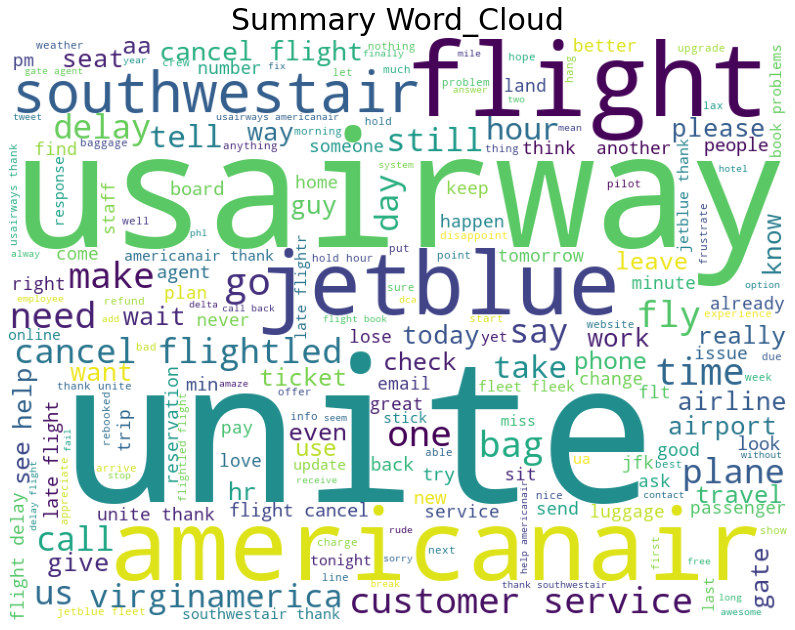

```python
# Let's do a word cloud for the entire set of tweets, whether positive, neatral, or negative.

# The 'text' feature has the cleaned text from the various tweets
show_wordcloud(tweets, 'text', 'Summary Word_Cloud')
```

**Observations:**

- The names of the airlines themselves is significant and shows up in the word cloud.
- Although the airline JetBlue is not even in the set of airlines under study, it's name comes up prominently. Perhaps there is a reference to JetBlue in many of the tweets, perhaps as a comparison to other airlines.
- The three airlines US Airways, United, and American have the most tweets and they show up prominently in the word cloud.
- We have seen that customer service is an area of a lot of negative tweets, and it shows up as one of the more important terms.
- Flight cancelation also shows up as an important element in the tweets.

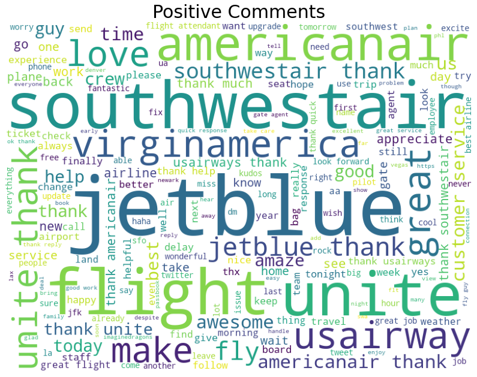

```python
# Now let's look at the word cloud for the set of positive tweets
show_wordcloud(tweets[tweets.airline_sentiment == "positive"], feature='text', title = "Positive Comments")
```

**Observations:**

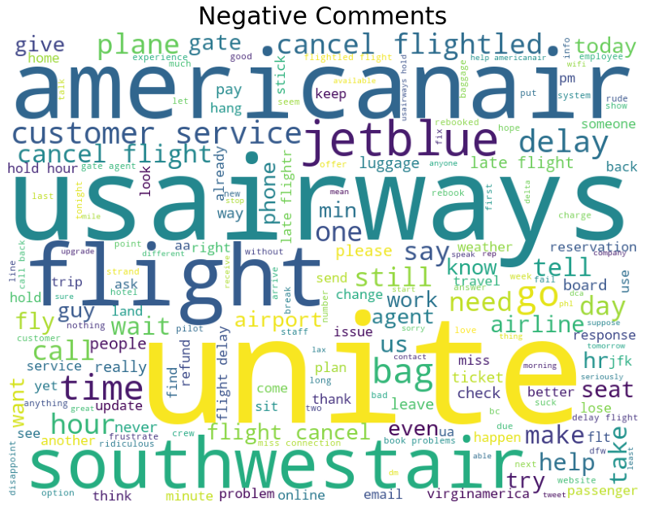

```python
# Now let's look at the word cloud for the set of negative tweets
show_wordcloud(tweets[tweets.airline_sentiment == "negative"], feature='text', title = "Negative Comments")
```

**Observations:**

- We see that the airlines that get the most negative tweets have shown up prominently in the negative sentiment coud including US Airways, American, and United.
- Other terms that have negative vibe have shown up like 'cancel', 'time', 'flight', 'need', 'delay'.
- The term 'time' could be related to flights not being on time.

## **Model Building**

### **Building the model based on CountVectorizer and Random Forest**

Before I can do the model and analysis, I need to convert the text-based sentiment labels into numeric values, so that we can do numeric classifications.

```python
# Define a function to convert text sentiment to number
def get_score(sentiment):
  if sentiment == 'negative':
    return 1
  if sentiment == 'neutral':
    return 2
  return 3
```

```python
# Generate the set of numeric labels needed for the analysis
labels = tweets['airline_sentiment'].apply(lambda x: get_score(x))
```

```python
# Vectorization (Convert text data to numbers).
bow_vec = CountVectorizer(max_features=2000)                # Keep only 2000 features as number of features will increase the processing time.
data_features = bow_vec.fit_transform(tweets['text'])

data_features = data_features.toarray()                     # Convert the data features to array.
```

```python
# Verify that the feature set is limited to 2000 columns and 14,600 rows (the set of tweets data)
data_features.shape
```

```
(14640, 2000)
```

```python
# Split data into training and testing set.

# Note, I am not going to touch the testing data set till I have got myself a good model through
# K-fold cross-validation. Using the best model obtained via the k-fold cross-validation, I will
# evaluate the model against the test data.

X_train, X_test, y_train, y_test = train_test_split(data_features, labels, test_size=0.3, random_state=11)
```

```python
# Use a random forest classifier to do the modeling
forest = RandomForestClassifier(n_estimators=10, n_jobs=4)

# Fit the model based on the training set
forest = forest.fit(X_train, y_train)

print(forest)
print('Average accuracy score from 5-fold cross validation:', np.mean(cross_val_score(forest, X_train, y_train, cv=5)))
```

```
RandomForestClassifier(bootstrap=True, ccp_alpha=0.0, class_weight=None,
                       criterion='gini', max_depth=None, max_features='auto',
                       max_leaf_nodes=None, max_samples=None,
                       min_impurity_decrease=0.0, min_impurity_split=None,
                       min_samples_leaf=1, min_samples_split=2,
                       min_weight_fraction_leaf=0.0, n_estimators=10, n_jobs=4,
                       oob_score=False, random_state=None, verbose=0,
                       warm_start=False)
Average accuracy score from 5-fold cross validation: 0.741706674284898
```

### **Define a set of utility functions to make it easy to do some repeatable activities**

```python
# Define a reusable function to make it easy to plot the errors for the various models
# It also returns the number of estimators that lead to optimal learning (min error)

def find_optimal_learner(cross_val_scores):
  # plotting the error as k increases
  base_ln = [x for x in range(1, 25)]
  error = [1 - score for score in cross_val_scores]                  #error corresponds to each nu of estimator
  optimal_learners = base_ln[error.index(min(error))]                #Selection of optimal nu of n_estimator corresponds to minimum error.
  plt.plot(base_ln, error)                                           #Plot between each nu of estimator and misclassification error
  xy = (optimal_learners, min(error))
  plt.annotate('(%s, %s)' % xy, xy = xy, textcoords='data')
  plt.xlabel("Number of base learners")
  plt.ylabel("Misclassification Error")
  plt.show()
  return optimal_learners
```

```python
# Define a utility function to display the confusion matrix

def display_confusion_matrix(y_test, result):
  # Finally, time to plot the results as a confusion matrix
  conf_mat = confusion_matrix(y_test, result)

  print(conf_mat)

  print(metrics.f1_score(y_test, result,average='micro'))

  display_results = ['negative', 'neutral', 'positive']
  df_cm = pd.DataFrame(conf_mat, index = display_results, columns = display_results)

  plt.figure(figsize = (10,7))
  sns.heatmap(df_cm, annot=True, fmt='g')
```

### **Model tuning using different trees with different number of estimators**

```python
# 5 - Fold Cross Validation.
cv_scores = []
for est_count in range(1, 25):
    clf = RandomForestClassifier(n_estimators = est_count)
    scores = cross_val_score(clf, X_train, y_train, cv = 5, scoring = 'accuracy')
    cv_scores.append(scores.mean())
```

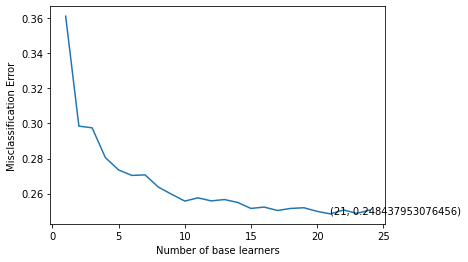

```
Optimal learner estimators: 21
```

```python
# Plot errors from each of the models that were used for optimization and find the optimal learner
optimal_learners = find_optimal_learner(cv_scores)
print('Optimal learner estimators:', optimal_learners)
```

```python
# Training the best model and calculating accuracy on test data.
optimal_clf = RandomForestClassifier(n_estimators = optimal_learners)
optimal_clf.fit(X_train, y_train)
optimal_clf.score(X_test, y_test)
```

```
0.7495446265938069
```

**Observation:** The tuned model has given me a 75% accuracy rate with the test data, which is quite good.

```python
result =  optimal_clf.predict(X_test)                  #saving the prediction on test data as a result
```

```
[[2447  230   83]
 [ 398  431   93]
 [ 183  113  414]]
0.7495446265938069
```

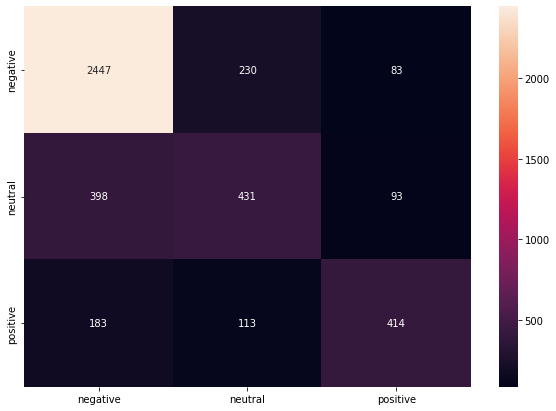

```python
# Finally, time to plot the results as a confusion matrix
display_confusion_matrix(y_test, result)
```

### **Word Cloud of top 40 important features from the CountVectorizer + Random Forest based model**

```python
# Create a utility function to be able to extract the most important features
def extract_imp_features(vec, clf):
  all_features = vec.get_feature_names()              #Instantiate the feature from the vectorizer
  top_features=''                                         # Addition of top 40 feature into top_feature after training the model
  feat=clf.feature_importances_
  features=np.argsort(feat)[::-1]
  for i in features[0:40]:
      top_features+=all_features[i]
      top_features+=' '
  return top_features
```

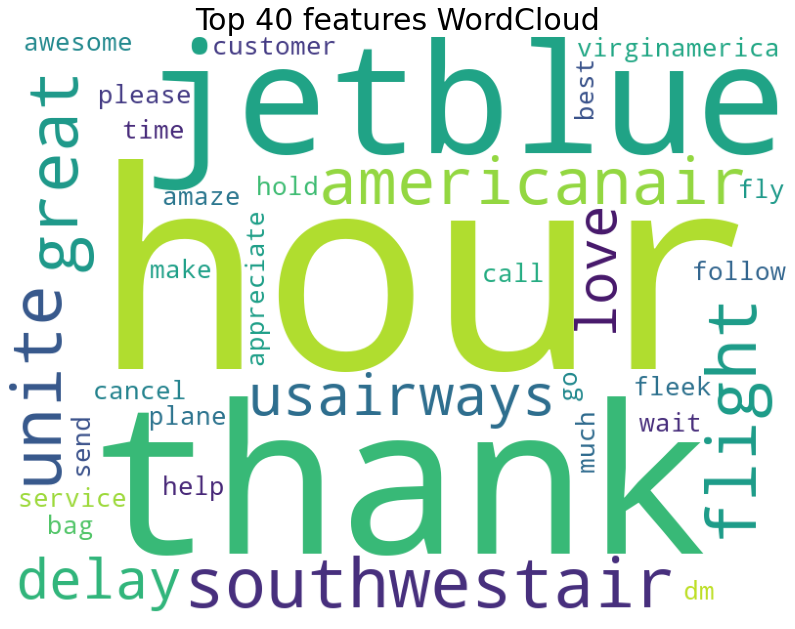

```python
# Use a previously defined function to display the word cloud easily
top_features = extract_imp_features(bow_vec,optimal_clf)
show_wordcloud_text(top_features, 'Top 40 features WordCloud')
```

**Observation:**

- It is interesting to see that although there are more tweets with negative sentiments, the top features are associated with positive sentiments. For example, 'thank', 'awesome', 'appreciate', 'amaze', 'best'.
- It is also interesting to see that JetBlue has a very prominent reference in the tweets and shows up as one of the top features.
- The top feature is 'hour', which by itself is neutral in sentiment.
- Some negative sentiments that have also shown up as important features are 'delay', 'cancel', and 'hold'.
- The CountVectorizer has actually done a pretty good job of identifying important features in the tweets.

### **Term Frequency(TF) - Inverse Document Frequency(IDF)**

```python
# Using TfidfVectorizer to convert text data to numbers.

vectorizer = TfidfVectorizer(max_features=2000)
data_features = vectorizer.fit_transform(tweets['text'])

data_features = data_features.toarray()
```

```python
# Verify that the feature set is limited to 2000 columns and 14,600 rows (the set of tweets data)
data_features.shape
```

```
(14640, 2000)
```

```python
# Split data into training and testing set. We had previously generated the 'label' data, so no need to generate it again.
# We will do our validation using k-fold cross-validation and not touch the test data till have found an optimal model.

X_train, X_test, y_train, y_test = train_test_split(data_features, labels, test_size=0.3, random_state=11)
```

```python
# Create a random forest classifier to do the modeling and analysis
forest = RandomForestClassifier(n_estimators=10, n_jobs=4)

# Fit the model based on the training data
forest = forest.fit(X_train, y_train)

print(forest)
print('Average accuracy score from 5-fold cross validation:', np.mean(cross_val_score(forest, X_train, y_train, cv=5)))
```

```
RandomForestClassifier(bootstrap=True, ccp_alpha=0.0, class_weight=None,
                       criterion='gini', max_depth=None, max_features='auto',
                       max_leaf_nodes=None, max_samples=None,
                       min_impurity_decrease=0.0, min_impurity_split=None,
                       min_samples_leaf=1, min_samples_split=2,
                       min_weight_fraction_leaf=0.0, n_estimators=10, n_jobs=4,
                       oob_score=False, random_state=None, verbose=0,
                       warm_start=False)
Average accuracy score from 5-fold cross validation: 0.7479511480912759
```

### **Model tuning using different trees with different number of estimators**

```python
# 5 - Fold Cross Validation.
cv_scores = []
for est_count in range(1, 25):
    clf = RandomForestClassifier(n_estimators = est_count)
    scores = cross_val_score(clf, X_train, y_train, cv = 5, scoring = 'accuracy')
    cv_scores.append(scores.mean())
```

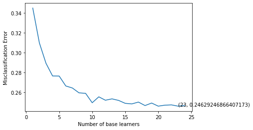

```
Optimal learner estimators: 23
```

```python
# Plot errors from each of the models that were used for optimization and find the optimal learner
optimal_learners = find_optimal_learner(cv_scores)
print('Optimal learner estimators:', optimal_learners)
```

```python
# Training the best model and calculating accuracy on test data.
optimal_clf = RandomForestClassifier(n_estimators = optimal_learners)
optimal_clf.fit(X_train, y_train)
optimal_clf.score(X_test, y_test)
```

```
0.7584244080145719
```

**Observation:** The tuned model has given me a 76% accuracy rate with the test data, which is quite good. In fact, this is 1% better than what we previously obtained.

```python
result =  optimal_clf.predict(X_test)                  #saving the prediction on test data as a result
```

```
[[2568  140   52]
 [ 467  393   62]
 [ 238  102  370]]
0.7584244080145719
```

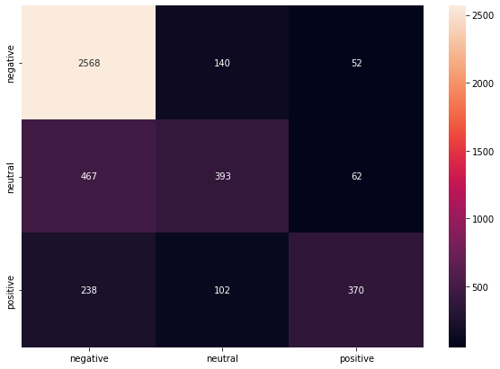

```python
# Finally, time to plot the results as a confusion matrix
display_confusion_matrix(y_test, result)
```

### **Word Cloud of top 40 important features from the TfidfVectorizer + Random Forest based model**

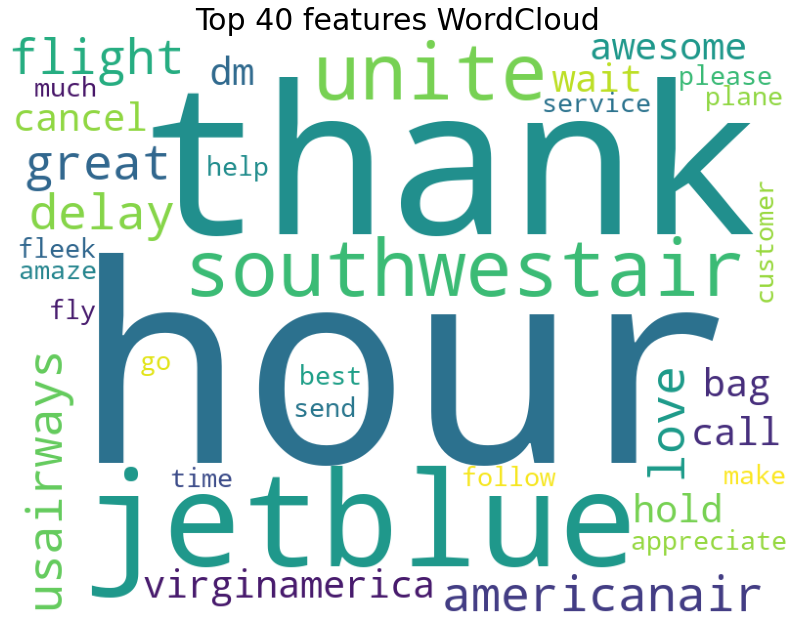

```python
# Use a previously defined function to display the word cloud easily
top_features = extract_imp_features(vectorizer,optimal_clf)
show_wordcloud_text(top_features, 'Top 40 features WordCloud')
```

**Observation:**

- The TF-IDF vectorizer has done a better job than CountVentorizer in identifying the most important features. The majority sentiments were negative, and we have prominently captured many of these sentiments: 'delay', ''cancel', 'wait', 'hold', 'customer', 'service'.
- It has also captured many positive sentiments, most prominently 'thank', 'great', 'love', 'awesome', 'appreciate'.
- This vectorizer also capture JetBlue as an important feature.
- The top feature is once again 'hour', which by itself is neutral in sentiment.
- All of the airlines names have again showed up, but they are a little less prominent than what we got from the CountVectorizer.

## **Summary**

- I have successfully cleaned and pre-processed tweets to be able to extract features and create classifiers.
- The majority of tweets have negative sentiments for the airlines, with the worst airlines being US Airways and the best airlines being Virgin America.
- The biggest complaints are about customer service, followed by late flight, cancelled flight, and lost luggage.
- The two vectorizers, CuntVenctorizer and TfidfVectorizer, both did a good ob of extracting the most important features. The TfidfVectorizer did a better job in extracting the negative sentiments more prominently, which is a better reflection of the general sentiment of the tweets.
- The classification models gave us fairly accurate results, with CountVectorizer+random forest giving 75% accuracy, and TfidfVectorizer+random forest giving us 76% accuracy.
- Both rounds of classification were done carefully with validation done through k-fold cross-validation on training data set, thus avoiding data leakage into the test data.
- Both models started off with an initial radom forest tree and were then optimized to get the optimal learner. The optimal learner was then used to train the model and test against the test data.
- I limited the max feature set to 2000 for the model analysis. I can possibly increase the number of features (with additional compute and time cost) to see if the effectiveness of the classifier model can be improved.
- I was not able to determine why 'JetBlue' showed up so prominently as a feature, and I need to look at all the tweets to see why it shows up so prominently.